# Incarceration Trends in the U.S.

Yoonseo Nam

2024-05-23

# **Introduction**

The United States has the highest incarceration rate in the world, significantly impacting people of color, particularly Black Americans. This phenomenon is a consequence of both historical and contemporary racism, manifesting in disproportionately high incarceration rates for these communities. To comprehend the breadth and depth of this issue, it’s essential to analyze the trends in incarceration rates over time, considering factors such as race, gender, and geography.

This report leverages data from the Vera Institute to examine these trends and disparities in U.S. incarceration rates. By focusing on variables such as jail population, time (year), and race, we aim to illuminate patterns of inequality and provide insights for potential policy interventions and public awareness initiatives.

## Description of the Variables

### Total Jail Population (total_jail_pop):

**Measure of Incarceration**: This variable represents the aggregate number of people incarcerated in jails within various states and over different years. **Significance**: Analyzing the total jail population provides a comprehensive view of the scale of incarceration. It helps identify overall trends and patterns, such as increases or decreases in the jail population over time.

### Year (year):

**Measure of Time**: The year variable indicates the specific year for which the jail population data is recorded. **Significance**: Examining trends over time allows us to observe how incarceration rates have evolved. This temporal analysis can reveal significant shifts in policy impacts or social dynamics affecting incarceration rates.

### Race (e.g., black_jail_pop, white_jail_pop):

**Measure of Demographic Disparity**: These variables represent the jail populations broken down by racial groups: Black and White. **Significance**: Analyzing these variables is crucial for understanding racial disparities in incarceration rates. Given the historical and systemic nature of racial discrimination in the U.S., these variables highlight how different communities are affected by incarceration policies.

### State (state):

**Geographical Measure**: The state variable indicates the U.S. state for which the data is recorded. **Significance**: Analyzing data by state helps identify geographical variations in incarceration rates. State-specific policies and practices can significantly influence these rates, making this variable essential for a localized understanding of incarceration trends.

# **Summary Information**

The analysis of the jail population data reveals several key insights into incarceration trends and racial disparities in the United States. Below are five relevant values calculated from the data:

1. Average Jail Population Across Counties (2018)

In 2018, the average jail population across all counties in the dataset was approximately 249 inmates. This average helps us understand the typical scale of incarceration at the county level during that year.

jail_pop_2018 <- us_jail_pop_data %>% filter(year == 2018)

average_jail_pop_2018 <- jail_pop_2018 %>% summarise(avg_jail_pop = mean(total_jail_pop, na.rm = TRUE))

2. Highest Jail Population by County (2018)

In 2018, Los Angeles County, California, had the highest jail population with 17,208 inmates. This highlights significant regional disparities, as some counties have disproportionately large incarcerated populations.

highest_jail_pop_2018 <- jail_pop_2018 %>% filter(total_jail_pop == max(total_jail_pop, na.rm = TRUE))

lowest_jail_pop_2018 <- jail_pop_2018 %>% filter(total_jail_pop == min(total_jail_pop[total_jail_pop > 0], na.rm = TRUE))

4. Change in Total Jail Population Over the Last 10 Years (2008-2018):

From 2008 to 2018, the total jail population in the United States decreased by approximately 41,075 individuals. This decrease reflects recent efforts and policy changes aimed at reducing mass incarceration.

total_jail_pop_by_year <- us_jail_pop_data %>% group_by(year) %>% summarise(total_jail_pop = sum(total_jail_pop, na.rm = TRUE))

jail_pop_change <- total_jail_pop_by_year %>% filter(year %in% c(2008, 2018)) jail_pop_change$change <- jail_pop_change$total_jail_pop - lag(jail_pop_change$total_jail_pop)

5. Racial Disparities in Jail Population (2018):

In 2018, Black Americans made up 33% of the total jail population, despite comprising only about 13.4% of the U.S. population. This stark disparity underscores the racial inequalities present within the U.S. criminal justice system.

racial_disparities_2018 <- jail_pop_2018 %>% summarise( total_black_jail_pop = sum(black_jail_pop, na.rm = TRUE), total_white_jail_pop = sum(white_jail_pop, na.rm = TRUE), total_jail_pop = sum(total_jail_pop, na.rm = TRUE) )

racial_disparities_2018 <- racial_disparities_2018 %>% mutate( percent_black = (total_black_jail_pop / total_jail_pop) * 100, percent_white = (total_white_jail_pop / total_jail_pop) * 100, )

# **Dataset Description**

### Who collected the data?

The data was collected by the Vera Institute of Justice, an organization known for its research and advocacy in criminal justice reform.

### How was the data collected or generated?

The data was aggregated from various sources, including government reports, official jail records, and administrative data from county and state correctional facilities. The Vera Institute compiled these records to create a unified dataset that reflects the jail populations at different times and across different jurisdictions.

### Why was the data collected?

The primary purpose of collecting this data was to shed light on the scope and scale of incarceration in the United States. By providing detailed information on jail populations, the Vera Institute aims to support research and advocacy efforts aimed at reducing mass incarceration and addressing systemic racial disparities in the justice system.

### How many observations (rows) are in the data?

The dataset contains approximately 153,811 observations (rows).

nrow(us_jail_pop_data)

### How Many Features (Columns) Are in the Data?

The dataset includes 28 features (columns).

### Ethical Questions or Questions of Power

Working with this data requires careful consideration of ethical questions and power dynamics. Key issues include the potential for misuse of the data to reinforce negative stereotypes or justify punitive policies. It is also important to consider the privacy and rights of incarcerated individuals, as their data should be handled with sensitivity and confidentiality. Researchers must ensure that their analysis and interpretation do not inadvertently perpetuate biases or contribute to the stigmatization of marginalized communities.

### Possible Limitations

Some records may have missing or incomplete data, which can affect the accuracy and reliability of the analysis. Certain counties or states may have inconsistent reporting practices, leading to gaps in the data. Another limitation is the way racial and ethnic categories are defined and recorded as they may not capture the full complexity of individuals’ identities. This can lead to oversimplified or misleading conclusions about racial disparities.

### **Dataset**

jail_pop_data <- read.csv(“/Users/yoonseonam/Documents/Info201code/a4-incarceration-assignment-yseokul/us_jail_pop_data.csv”)

Number of records nrow(us_jail_pop_data)

Column data str(us_jail_pop_data)

# **Trend Analysis: Jail Population Trends Over Time by Race**

[figure not shown]

race_data <- us_jail_pop_data %>% group_by(year) %>% summarise( total_black_jail_pop = sum(black_jail_pop, na.rm = TRUE), total_white_jail_pop = sum(white_jail_pop, na.rm = TRUE), total_latinx_jail_pop = sum(latinx_jail_pop, na.rm = TRUE) )

race_data_long <- race_data %>% pivot_longer(cols = c(total_black_jail_pop, total_white_jail_pop, total_latinx_jail_pop), names_to = “race”, values_to = “total_jail_pop”)

# **Comparative Analysis: Relationship Between Total Jail Population and Black Jail Population**

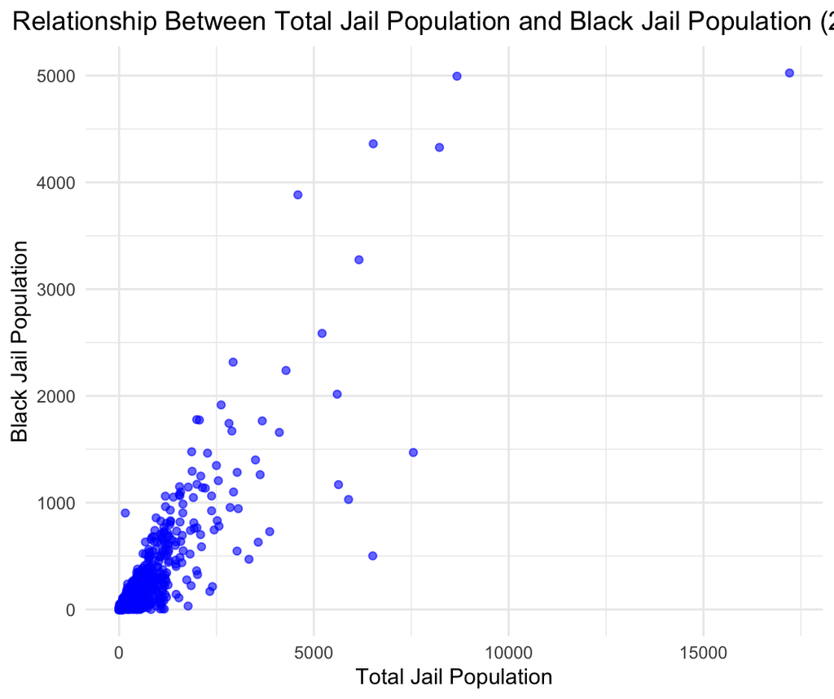

comparative analysis

> The variable comparison chart, which compares the total jail population and the Black jail population using a scatter plot, was designed to reveal potential disparities in incarceration rates between the overall population and specific racial groups. There is a clear positive correlation, indicating that as the total jail population increases, the Black jail population also increases. This can highlight the proportional representation of Black individuals in the overall jail population.

scatter_data <- jail_pop_2018 %>% select(county_name, total_jail_pop, black_jail_pop) %>% filter(!is.na(total_jail_pop) & !is.na(black_jail_pop))

ggplot(scatter_data, aes(x = total_jail_pop, y = black_jail_pop)) + geom_point(alpha = 0.6, color = “blue”) + labs( title = “Relationship Between Total Jail Population and Black Jail Population (2018)”, x = “Total Jail Population”, y = “Black Jail Population” ) + theme_minimal() + theme( plot.title = element_text(hjust = 0.5) )

# **Geographical Analysis:**

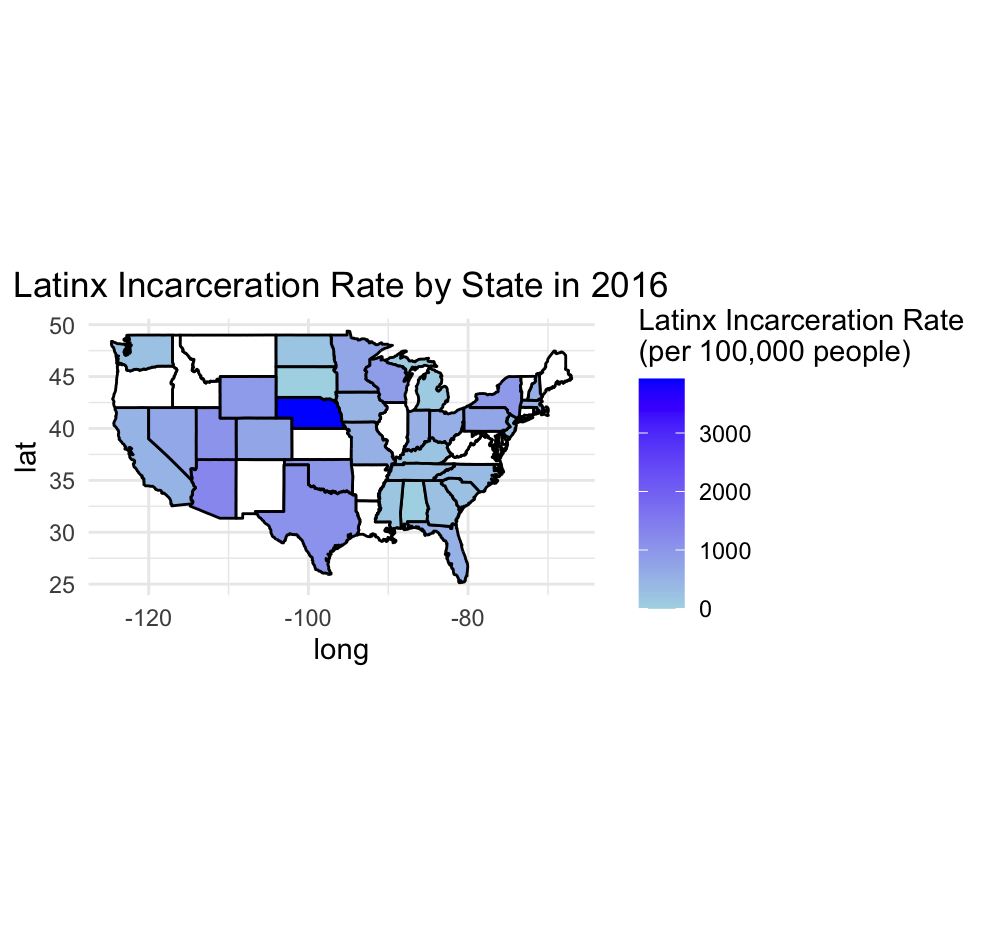

> Analyzing incarceration rates, particularly among specific demographic groups like Latinx individuals, is crucial for understanding systemic inequalities within the criminal justice system and identifying areas for reform. By visualizing Latinx incarceration rates by state, we can discern patterns that may reflect disparities in law enforcement practices, sentencing policies, and access to legal representation. The map provides a snapshot of how Latinx individuals are disproportionately affected by incarceration across different regions of the United States. Patterns may reveal states or regions with significantly higher or lower Latinx incarceration rates, highlighting areas where interventions such as community-based programs, policy reforms, and increased support for marginalized communities could be particularly impactful. Additionally, the map can serve as a tool for advocacy efforts aimed at addressing racial and ethnic disparities within the criminal justice system, ultimately contributing to the pursuit of equitable and just outcomes for all individuals.

Load the data url <- “https://github.com/melaniewalsh/Neat-Datasets/blob/main/us-prison-pop.csv?raw=true” prison_data <- read_csv(url) %>% clean_names()

Clean and filter the data prison_data <- prison_data %>% filter(!is.na(latinx_prison_pop) & !is.na(latinx_pop_15to64)) %>% mutate(latinx_incarceration_rate = (latinx_prison_pop / latinx_pop_15to64) * 100000)

Filter for the year 2016 prison_data_2016 <- prison_data %>% filter(year == 2016)

Aggregate data at the state level state_data <- prison_data_2016 %>% group_by(state) %>% summarise(latinx_incarceration_rate = mean(latinx_incarceration_rate, na.rm = TRUE))

Prepare data for mapping using ggplot2’s map_data state_map_data <- map_data(“state”)

Convert state names to lowercase for merging state_data <- state_data %>% mutate(region = tolower(state.name[match(state, state.abb)]))

Merge map data with incarceration data map_data <- state_map_data %>% left_join(state_data, by = “region”)

Create the map map <- ggplot(map_data, aes(x = long, y = lat, group = group, fill = latinx_incarceration_rate)) + geom_polygon(color = “black”) + scale_fill_gradientn(colors = c(“lightblue”, “blue”), na.value = “white”, name = “Latinx Incarceration Rate(per 100,000 people)”) + theme_minimal() + labs(title = “Latinx Incarceration Rate by State in 2016”) + ggeasy::easy_center_title() + coord_fixed(1.3) # Use a map-based coordinate system to set the aspect ratio

Display the map print(map)